# Employee Satisfaction Survey Data

Authors: Kubíček Max, Kuzmina Diana, Kuznetsov Andrei, Bajukov Alexej, Pavel Lyapin (seminar on Thursday at 16:15)

# Introduction:

Business Value of Addressing the Problem with Machine Learning: Utilizing machine learning on the Employee Satisfaction Survey dataset can provide numerous benefits to businesses. By leveraging advanced analytics, companies can gain valuable insights into the factors affecting employee satisfaction, leading to improved employee engagement, retention, and overall organizational success. Machine learning models can help identify patterns and correlations within the dataset, allowing companies to make data-driven decisions to enhance workplace conditions, optimize resource allocation, and create targeted interventions to address specific areas of concern. Predictive models may also enable proactive measures to prevent employee turnover, ultimately contributing to a healthier and more productive work environment.

The dataset used for this analysis is sourced from the Kaggle and can be accessed at the following link: https://www.kaggle.com/datasets/redpen12/employees-satisfaction-analysis

```python
import numpy as np
import pandas as pd
import matplotlib.pyplot as plt
import seaborn as sns
from sklearn.model_selection import train_test_split
```

```python
df = pd.read_csv('Employee_Attrition.csv')
df.head()
```

|  | Emp ID | satisfaction_level | last_evaluation | number_project | average_montly_hours | time_spend_company | Work_accident | promotion_last_5years | dept | salary |
| --- | --- | --- | --- | --- | --- | --- | --- | --- | --- | --- |
| 0 | 1.0 | 0.38 | 0.53 | 2.0 | 157.0 | 3.0 | 0.0 | 0.0 | sales | low |
| 1 | 2.0 | 0.80 | 0.86 | 5.0 | 262.0 | 6.0 | 0.0 | 0.0 | sales | medium |
| 2 | 3.0 | 0.11 | 0.88 | 7.0 | 272.0 | 4.0 | 0.0 | 0.0 | sales | medium |
| 3 | 4.0 | 0.72 | 0.87 | 5.0 | 223.0 | 5.0 | 0.0 | 0.0 | sales | low |
| 4 | 5.0 | 0.37 | 0.52 | 2.0 | 159.0 | 3.0 | 0.0 | 0.0 | sales | low |

# Customization:

*Instance of Interest:* As an "Instance of Interest," we have selected employees who reported experiencing a work-related accident (Work_accident = 1) in our employee satisfaction dataset. Analyzing these instances allows for a targeted investigation into the factors contributing to work accidents, aiding in the identification of patterns and the development of focused safety measures. Instances with Work_accident = 0 provide insights into successful safety practices. Understanding these instances is crucial for improving workplace safety and preventing work-related accidents.

*Attribute of Interest:* The attribute of interest is " time_spend_company". This attribute provides valuable insights into the relationship between employee tenure and job satisfaction. Analyzing this information allows to understand how the duration of employment may impact satisfaction levels and contributes to the organization's ability to retain experienced and satisfied employees.

*Subset of Interest:* The "Subset of Interest" in our analysis is “promotion_last_5years”. Focusing on this subset allows for a targeted examination of how recent promotions correlate with job satisfaction. It provides insights into the impact of career advancement on employees' overall satisfaction levels, helping identify factors contributing to a positive work experience for those who have received promotions. This subset analysis can be instrumental in understanding the effectiveness of the promotion process in fostering employee satisfaction within the organization.

# Cost matrix

```python
cost_matrix = {
    'Classification Outcome': ['True Positive (TP)', 'True Negative (TN)', 'False Positive (FP)', 'False Negative (FN)'],
    'Description': [
        "Correctly identifying a satisfied employee",
        "Correctly identifying a dissatisfied employee",
        "Incorrectly classifying a dissatisfied employee as satisfied",
        "Incorrectly classifying a satisfied employee as dissatisfied"
    ],
    'Cost': ['0', '0', 'Moderate', 'High']
}

cost_matrix_df = pd.DataFrame(cost_matrix)
print(cost_matrix_df)
```

```
  Classification Outcome                                        Description  \
0     True Positive (TP)         Correctly identifying a satisfied employee
1     True Negative (TN)      Correctly identifying a dissatisfied employee
2    False Positive (FP)  Incorrectly classifying a dissatisfied employe...
3    False Negative (FN)  Incorrectly classifying a satisfied employee a...

       Cost
0         0
1         0
2  Moderate
3      High
```

"True Positives (TP) and True Negatives (TN) both incur zero cost, reflecting accurate classifications of satisfied and dissatisfied employees. False Positives (FP) carry a moderate cost due to the potential misinterpretation of satisfaction levels without a direct negative impact on the work environment. In contrast, False Negatives (FN) are assigned a high cost. This accounts for the repercussions of misclassifying a satisfied employee as dissatisfied, potentially leading to a significant underestimation of their job-related needs and satisfaction. Such misclassifications could result in more substantial negative implications for employee engagement and organizational performance."

# Data Exploration

## Correlation plot

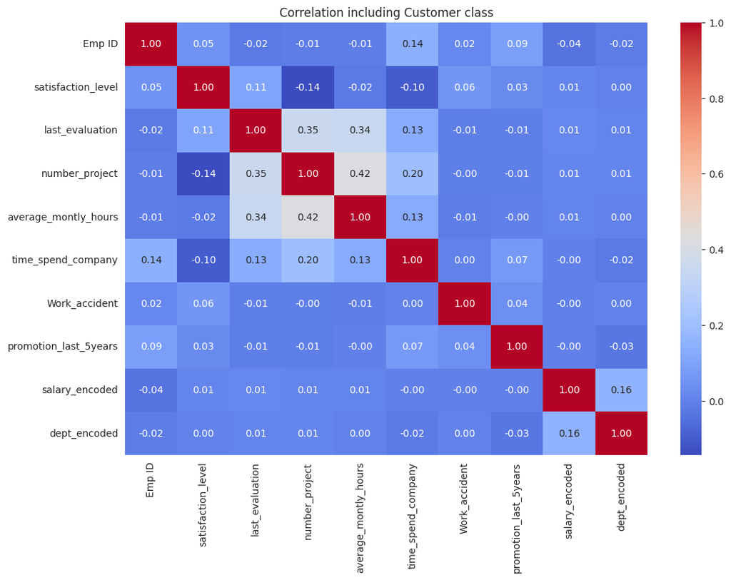

```python
from sklearn.preprocessing import LabelEncoder

df = pd.read_csv('Employee_Attrition.csv')

dataset_numerical = df.copy()
label_encoder = LabelEncoder()

#conversion to numerical values
dataset_numerical['salary_encoded'] = label_encoder.fit_transform(df['salary'])
dataset_numerical['dept_encoded'] = label_encoder.fit_transform(df['dept'])

numerical_columns = dataset_numerical.select_dtypes(include=['float64', 'int64']).columns
correlation_matrix = dataset_numerical[numerical_columns].corr()

plt.figure(figsize=(12, 8))
sns.heatmap(correlation_matrix, annot=True, fmt='.2f', cmap='coolwarm')
plt.title('Correlation including Customer class')
plt.show()
```

The plot includes all numerical variables from dataset, plus the salary and dept which has been encoded into numerical format.

Each cell in the heatmap displays a correlation coefficient within the -1 to 1 range, signifying the intensity and direction of the connection between two variables. We usually distinguish between three main coeficient values:

- A positive correlation (near +1) signifies that as one variable rises, the other typically follows suit.
- Conversely, a negative correlation (near -1) suggests that as one variable increases, the other tends to decrease.
- A correlation around 0 indicates no clear linear relationship between the variables.

## Histograms

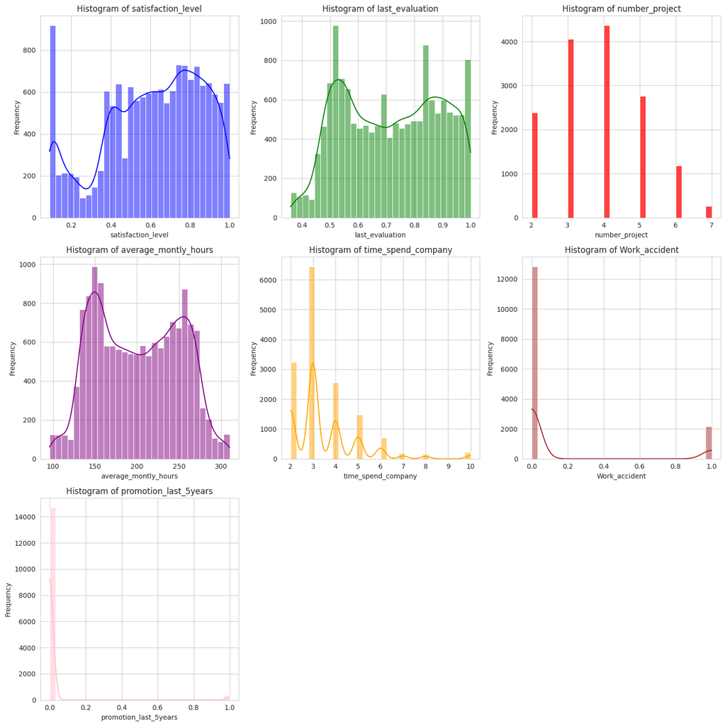

```
Summary of the Dataset:
--- satisfaction_level ---
Count: 14999.0
Mean: 0.61
Standard Deviation: 0.25
Minimum Value: 0.09
25th Percentile: 0.44
Median (50th Percentile): 0.64
75th Percentile: 0.82
Maximum Value: 1.0


--- last_evaluation ---
Count: 14999.0
Mean: 0.72
Standard Deviation: 0.17
Minimum Value: 0.36
25th Percentile: 0.56
Median (50th Percentile): 0.72
75th Percentile: 0.87
Maximum Value: 1.0


--- number_project ---
Count: 14999.0
Mean: 3.80
Standard Deviation: 1.23
Minimum Value: 2.0
25th Percentile: 3.0
Median (50th Percentile): 4.0
75th Percentile: 5.0
Maximum Value: 7.0


--- average_montly_hours ---
Count: 14999.0
Mean: 201.05
Standard Deviation: 49.94
Minimum Value: 96.0
25th Percentile: 156.0
```

[output cut: 21 more lines]

```
25th Percentile: 0.0
Median (50th Percentile): 0.0
75th Percentile: 0.0
Maximum Value: 1.0


--- promotion_last_5years ---
Count: 14999.0
Mean: 0.02
Standard Deviation: 0.14
Minimum Value: 0.0
25th Percentile: 0.0
Median (50th Percentile): 0.0
75th Percentile: 0.0
Maximum Value: 1.0
```

```python
# Set the style of the plots
sns.set_style("whitegrid")

# Identifying numerical columns in the dataset, excluding 'Emp ID'
numerical_columns = df.select_dtypes(include=['float64', 'int64']).columns
numerical_columns = numerical_columns.drop('Emp ID')  # Adjust the column name if different

# Determining the number of rows needed for subplots (with 3 histograms per row)
colors = ['blue', 'green', 'red', 'purple', 'orange', 'brown', 'pink', 'gray', 'olive', 'cyan']

# Determining the number of rows needed for subplots (with 3 histograms per row)
num_rows = len(numerical_columns) // 3 + (len(numerical_columns) % 3 > 0)

# Creating a figure to hold multiple subplots
plt.figure(figsize=(15, 5 * num_rows))

for i, column in enumerate(numerical_columns):
    plt.subplot(num_rows, 3, i + 1)
    sns.histplot(df[column], kde=(column != 'number_project'), bins=30, color=colors[i % len(colors)])
    plt.title(f'Histogram of {column}')
    plt.xlabel(column)
    plt.ylabel('Frequency')

# Show the plots
plt.tight_layout()
plt.show()

# Function to describe each column in the dataset based on summary statistics
def describe_dataset(summary):
    for column in summary.columns:
        # Skip 'Emp ID' column
        if column == 'Emp ID':
            continue

        print(f"--- {column} ---")
        col_data = summary[column]

        # General Stats
        print(f"Count: {col_data['count']}")
        print(f"Mean: {col_data['mean']:.2f}")
        print(f"Standard Deviation: {col_data['std']:.2f}")
        print(f"Minimum Value: {col_data['min']}")
        print(f"25th Percentile: {col_data['25%']}")
        print(f"Median (50th Percentile): {col_data['50%']}")
        print(f"75th Percentile: {col_data['75%']}")
        print(f"Maximum Value: {col_data['max']}")


        print("\n")

# Usage
print("\nSummary of the Dataset:")
describe_dataset(df.describe())
```

## Interpretation of the results

## Correlation Plot

1. number_of_projects and monthly_hours: The correlation between these two features is high and the reason is obvious. The more number of projects an individual has the more hours he works.
2. last_evaluation and number_of_projects: The correlation between them is relatively high and this indicates that people with more assigned projects have higher perfomance score.
3. last_evaluation and average_monthly_hours: The correlation also is relatively high, because montly_hours can be transitivly derived from last_evaluation and this metric is almost indentical to average_monthly_hours.
4. number_of_projects and satisfaction_level: The metrics have low correlation and this indicates the fact that people with litle number of projects may have same level of satisfaction as people with a lot of projects.

## Histograms

### Satisfaction Level:

- **Histogram**: The distribution of satisfaction levels among employees. Look for peaks to understand common satisfaction levels.
- **Summary Stats**: The mean satisfaction level can give you an idea of overall employee contentment. A high standard deviation suggests wide variability in satisfaction.

### Last Evaluation:

- **Histogram**: Shows how employees' last evaluations are distributed. Are there clusters around certain scores?
- **Summary Stats**: The average score (mean) and the spread (standard deviation) indicate the overall performance level and its variation among employees.

### Number of Projects:

- **Histogram**: This reveals the common number of projects assigned to employees. Peaks show the most frequent assignments.
- **Summary Stats**: Mean value shows the average number of projects per employee. The spread indicates how evenly the projects are distributed.

### Average Monthly Hours:

- **Histogram**: Illustrates the distribution of the average number of hours worked per month. Look for clustering to identify standard working hours.
- **Summary Stats**: Mean hours give an idea of the overall workload, while the standard deviation shows how much this varies among employees.

### Time Spent in Company:

- **Histogram**: Reflects how long employees tend to stay at the company. Are there common tenure lengths?
- **Summary Stats**: The average tenure (mean) and the variation (standard deviation) can indicate employee retention and turnover rates.

### Work Accident:

- **Histogram**: Shows the frequency of work accidents.
- **Summary Stats**: The mean, close to 0 or 1, can indicate the overall safety environment in the company.

### Promotion in Last 5 Years:

- **Histogram**: Indicates how many employees were promoted in the last five years.
- **Summary Stats**: A mean close to 0 may suggest that promotions are rare.

## Data preprocessing

### Derive binary target attribute

```python
import pandas as pd

# Assuming your DataFrame is named df
# First, create the 'is_satisfied' column based on the satisfaction_level
df['is_satisfied'] = df['satisfaction_level'].apply(lambda x: 1 if x >= 0.5 else 0)

df['is_satisfied'] = df['is_satisfied'].astype(str)
print(df.head())
```

```
   Emp ID  satisfaction_level  last_evaluation  number_project  \
0     1.0                0.38             0.53             2.0
1     2.0                0.80             0.86             5.0
2     3.0                0.11             0.88             7.0
3     4.0                0.72             0.87             5.0
4     5.0                0.37             0.52             2.0

   average_montly_hours  time_spend_company  Work_accident  \
0                 157.0                 3.0            0.0
1                 262.0                 6.0            0.0
2                 272.0                 4.0            0.0
3                 223.0                 5.0            0.0
4                 159.0                 3.0            0.0

   promotion_last_5years   dept  salary is_satisfied
0                    0.0  sales     low            0
1                    0.0  sales  medium            1
2                    0.0  sales  medium            0
3                    0.0  sales     low            1
4                    0.0  sales     low            0
```

### Train test split

```python
df = pd.read_csv('Employee_Attrition.csv')

ctrain_dataset = 'train_dataset.csv'
test_dataset = 'test_dataset.csv'


train, test = train_test_split(df, test_size=0.2)
train.to_csv(ctrain_dataset, index=False)
test.to_csv(test_dataset, index=False)
```

### Train dataset

```python
from IPython.display import display


df_train = pd.read_csv(ctrain_dataset)

display(df_train)
```

|  | Emp ID | satisfaction_level | last_evaluation | number_project | average_montly_hours | time_spend_company | Work_accident | promotion_last_5years | dept | salary |
| --- | --- | --- | --- | --- | --- | --- | --- | --- | --- | --- |
| 0 | 6677.0 | 0.52 | 0.53 | 5.0 | 182.0 | 2.0 | 0.0 | 0.0 | technical | medium |
| 1 | 14775.0 | 0.10 | 0.77 | 7.0 | 291.0 | 4.0 | 0.0 | 0.0 | accounting | low |
| 2 | 14390.0 | 0.37 | 0.51 | 2.0 | 127.0 | 3.0 | 0.0 | 0.0 | sales | medium |
| 3 | 3487.0 | 0.85 | 0.67 | 4.0 | 228.0 | 4.0 | 0.0 | 0.0 | support | low |
| 4 | 7982.0 | 0.57 | 0.89 | 4.0 | 255.0 | 3.0 | 1.0 | 0.0 | technical | low |
| ... | ... | ... | ... | ... | ... | ... | ... | ... | ... | ... |
| 12624 | 7090.0 | 0.46 | 0.49 | 5.0 | 286.0 | 5.0 | 0.0 | 0.0 | product_mng | low |
| 12625 | 7367.0 | 0.61 | 0.59 | 4.0 | 247.0 | 2.0 | 0.0 | 0.0 | technical | medium |
| 12626 | 5015.0 | 0.92 | 1.00 | 3.0 | 212.0 | 2.0 | 0.0 | 0.0 | support | low |
| 12627 | 6351.0 | 0.79 | 0.60 | 5.0 | 223.0 | 3.0 | 0.0 | 0.0 | sales | low |
| 12628 | 870.0 | 0.38 | 0.57 | 2.0 | 152.0 | 3.0 | 1.0 | 0.0 | hr | low |

12629 rows × 10 columns

### Test dataset

```python
from IPython.display import display

df_test = pd.read_csv(test_dataset)

display(df_test)
```

|  | Emp ID | satisfaction_level | last_evaluation | number_project | average_montly_hours | time_spend_company | Work_accident | promotion_last_5years | dept | salary |
| --- | --- | --- | --- | --- | --- | --- | --- | --- | --- | --- |
| 0 | 11361.0 | 0.62 | 0.75 | 5.0 | 165.0 | 4.0 | 0.0 | 0.0 | sales | medium |
| 1 | 1002.0 | 0.11 | 0.85 | 6.0 | 267.0 | 4.0 | 0.0 | 0.0 | sales | medium |
| 2 | 7097.0 | 0.84 | 0.83 | 4.0 | 222.0 | 3.0 | 0.0 | 0.0 | RandD | medium |
| 3 | 14209.0 | 0.85 | 0.54 | 3.0 | 185.0 | 10.0 | 0.0 | 1.0 | management | high |
| 4 | 11238.0 | 0.24 | 0.50 | 4.0 | 282.0 | 4.0 | 1.0 | 0.0 | support | low |
| ... | ... | ... | ... | ... | ... | ... | ... | ... | ... | ... |
| 3153 | 7119.0 | 0.85 | 0.67 | 3.0 | 267.0 | 2.0 | 1.0 | 0.0 | sales | low |
| 3154 | 3304.0 | 0.27 | 0.62 | 6.0 | 136.0 | 3.0 | 0.0 | 0.0 | sales | high |
| 3155 | 6484.0 | 0.99 | 0.56 | 5.0 | 210.0 | 2.0 | 0.0 | 0.0 | RandD | medium |
| 3156 | 14759.0 | 0.37 | 0.50 | 2.0 | 141.0 | 3.0 | 0.0 | 0.0 | sales | low |
| 3157 | 14935.0 | 0.44 | 0.53 | 2.0 | 155.0 | 3.0 | 0.0 | 0.0 | product_mng | medium |

3158 rows × 10 columns

### Feature engineering

```python
#remove rows with missing values
df = df.dropna()
#remove the dept column
df = df.drop(columns=['dept'])
```

## Applying preprocessing on test data

```python
test_df = pd.read_csv(test_dataset)
test_df = test_df.dropna()
if 'dept' in test_df.columns:
    test_df = test_df.drop(columns=['dept'])
```

## Modeling

### Classifier 1 - Decision tree

```python
# Define a threshold for satisfaction
satisfaction_threshold = 0.5  # This is just an example, adjust it based on domain knowledge or business logic

# Create a new binary target column 'is_satisfied' based on the threshold
# If satisfaction_level is greater than the threshold, is_satisfied is True (or 1), else False (or 0)
df['is_satisfied'] = (df['satisfaction_level'] > satisfaction_threshold).astype(int)
```

```
Index(['Emp ID', 'satisfaction_level', 'last_evaluation', 'number_project',
       'average_montly_hours', 'time_spend_company', 'Work_accident',
       'promotion_last_5years', 'is_satisfied', 'salary_high', 'salary_low',
       'salary_medium'],
      dtype='object')
```

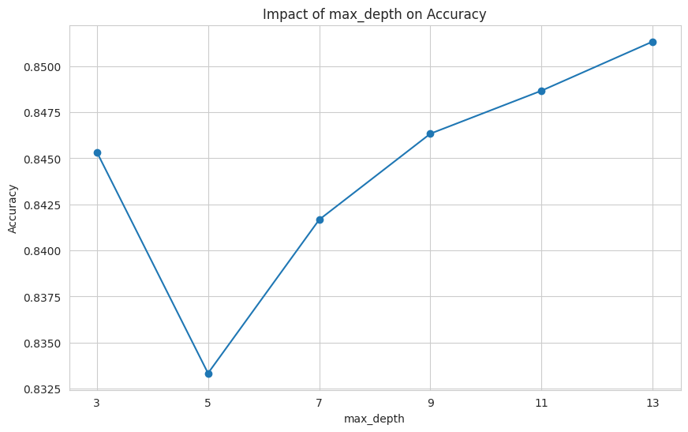

```
Best max_depth by Accuracy: 13
              precision    recall  f1-score   support

           0       0.81      0.70      0.75       952
           1       0.87      0.92      0.89      2048

    accuracy                           0.85      3000
   macro avg       0.84      0.81      0.82      3000
weighted avg       0.85      0.85      0.85      3000
```

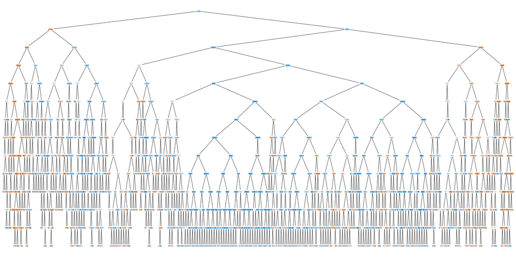

```python
from sklearn.metrics import mean_squared_error
from sklearn.tree import DecisionTreeClassifier, plot_tree
from sklearn.model_selection import train_test_split
from sklearn.metrics import accuracy_score, classification_report, confusion_matrix


# Now df has new columns like 'salary_low', 'salary_medium', 'salary_high'
if 'salary' in df.columns:
    df = pd.get_dummies(df, columns=['salary'])

print(df.columns)

# List of max_depth values to try
max_depth_values = [3, 5, 7, 9, 11, 13]

# Dictionary to store accuracy for each max_depth value
accuracy_scores = {}

# Selecting features and target
# (Assuming 'target' is a categorical variable in your dataset for classification)
features = ['time_spend_company', 'last_evaluation', 'number_project', 'average_montly_hours', 'Work_accident', 'promotion_last_5years', 'salary_low', 'salary_medium', 'salary_high']
target = 'is_satisfied'  # Replace with your actual target column name for classification

# Splitting the data into features (X) and target (y)
X = df[features]
y = df[target]

# Splitting the dataset into training and testing sets
X_train, X_test, y_train, y_test = train_test_split(X, y, test_size=0.2, random_state=42)

# Loop through each max_depth value
for max_depth in max_depth_values:
    # Train a decision tree classifier with the current max_depth
    dt_classifier = DecisionTreeClassifier(max_depth=max_depth, random_state=42)
    dt_classifier.fit(X_train, y_train)

    # Predicting on the test set
    y_pred = dt_classifier.predict(X_test)

    # Calculating accuracy
    accuracy = accuracy_score(y_test, y_pred)

    # Storing accuracy for the current max_depth value
    accuracy_scores[max_depth] = accuracy

# Plotting accuracy for each max_depth value
plt.figure(figsize=(10, 6))
plt.plot(list(accuracy_scores.keys()), list(accuracy_scores.values()), marker='o')
plt.title('Impact of max_depth on Accuracy')
plt.xlabel('max_depth')
plt.ylabel('Accuracy')
plt.xticks(max_depth_values)
plt.grid(True)
plt.show()

# Choose the best max_depth based on accuracy
best_max_depth = max(accuracy_scores, key=accuracy_scores.get)
print(f"Best max_depth by Accuracy: {best_max_depth}")

# Train a decision tree classifier with the best max_depth
dt_classifier = DecisionTreeClassifier(max_depth=best_max_depth, random_state=42)
dt_classifier.fit(X_train, y_train)

# Predicting on the test set
y_pred = dt_classifier.predict(X_test)

# Calculating and printing classification report and confusion matrix
print(classification_report(y_test, y_pred))
dt_conf_matrix= confusion_matrix(y_test, y_pred)

# Plotting the decision tree of the best model
plt.figure(figsize=(30,15))
plot_tree(dt_classifier, feature_names=features, class_names=True, filled=True)
plt.show()
```

```
Classification Report:
              precision    recall  f1-score   support

           0       0.81      0.70      0.75       952
           1       0.87      0.92      0.89      2048

    accuracy                           0.85      3000
   macro avg       0.84      0.81      0.82      3000
weighted avg       0.85      0.85      0.85      3000

Accuracy: 0.8513333333333334
Confusion Matrix:
```

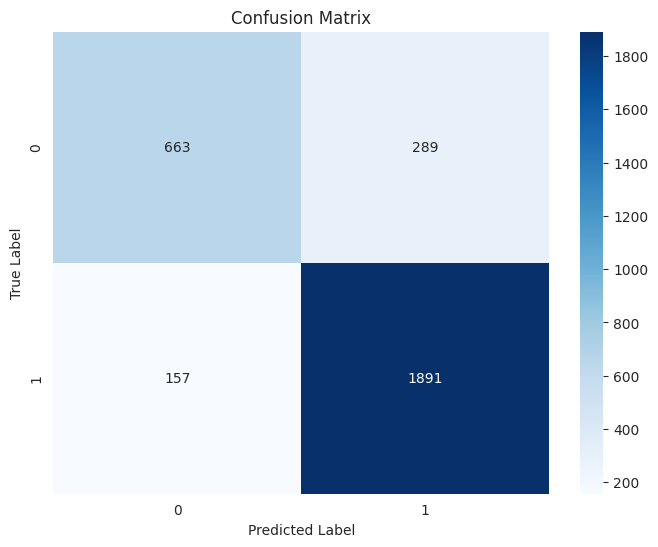

```python
# Predicting on the test set
y_pred = dt_classifier.predict(X_test)

# Calculating and printing classification metrics
print("Classification Report:")
print(classification_report(y_test, y_pred))

# Calculating and printing accuracy
accuracy = accuracy_score(y_test, y_pred)
print(f"Accuracy: {accuracy}")

# Calculating and printing the confusion matrix
print("Confusion Matrix:")

plt.figure(figsize=(8, 6))
sns.heatmap(dt_conf_matrix, annot=True, fmt='d', cmap='Blues')
plt.xlabel('Predicted Label')
plt.ylabel('True Label')
plt.title('Confusion Matrix')
plt.show()
```

### Classifier 2 - Random forest

```
n_estimators: 50, Accuracy: 0.8586666666666667
n_estimators: 100, Accuracy: 0.8596666666666667
n_estimators: 150, Accuracy: 0.8623333333333333
n_estimators: 200, Accuracy: 0.8616666666666667
n_estimators: 250, Accuracy: 0.8606666666666667
Best n_estimators by Accuracy: 150
              precision    recall  f1-score   support

           0       0.82      0.72      0.77       952
           1       0.88      0.93      0.90      2048

    accuracy                           0.86      3000
   macro avg       0.85      0.83      0.84      3000
weighted avg       0.86      0.86      0.86      3000
```

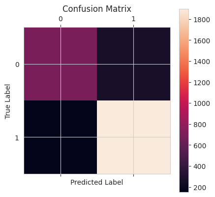

```python
from sklearn.ensemble import RandomForestClassifier

# Define your feature set and target variable
features = ['time_spend_company', 'last_evaluation', 'number_project', 'average_montly_hours', 'Work_accident','promotion_last_5years','salary_low','salary_medium','salary_high']
X = df[features]
y = df['is_satisfied']

# Splitting the dataset into training and testing sets
X_train, X_test, y_train, y_test = train_test_split(X, y, test_size=0.2, random_state=42)

# List of n_estimators values to try
n_estimators_values = [50, 100, 150, 200, 250]

# Dictionary to store accuracy for each n_estimators value
accuracy_scores = {}

# Loop through each n_estimators value
for n_estimators in n_estimators_values:
    # Train a Random Forest Classifier with the current n_estimators value
    rf_classifier = RandomForestClassifier(n_estimators=n_estimators, random_state=42)
    rf_classifier.fit(X_train, y_train)

    # Predicting on the test set
    y_pred = rf_classifier.predict(X_test)

    # Calculating accuracy
    accuracy = accuracy_score(y_test, y_pred)

    # Storing accuracy for the current n_estimators value
    accuracy_scores[n_estimators] = accuracy

# Print accuracy for each n_estimators value
for n_estimators, accuracy in accuracy_scores.items():
    print(f"n_estimators: {n_estimators}, Accuracy: {accuracy}")

# Optionally, select the best n_estimators value and train the final model
best_n_estimators = max(accuracy_scores, key=accuracy_scores.get)
print(f"Best n_estimators by Accuracy: {best_n_estimators}")

# Train the final Random Forest Classifier using the best n_estimators
rf_classifier = RandomForestClassifier(n_estimators=best_n_estimators, random_state=42)
rf_classifier.fit(X_train, y_train)

# Predict on the test set
y_pred_final = rf_classifier.predict(X_test)

# Print classification metrics
print(classification_report(y_test, y_pred_final))

# Plot confusion matrix
rf_conf_matrix = confusion_matrix(y_test, y_pred_final)
plt.matshow(rf_conf_matrix)
plt.title('Confusion Matrix')
plt.colorbar()
plt.ylabel('True Label')
plt.xlabel('Predicted Label')
plt.show()
```

```
Baseline Dummy Classifier Accuracy: 0.6826666666666666
              precision    recall  f1-score   support

           0       0.00      0.00      0.00       952
           1       0.68      1.00      0.81      2048

    accuracy                           0.68      3000
   macro avg       0.34      0.50      0.41      3000
weighted avg       0.47      0.68      0.55      3000
```

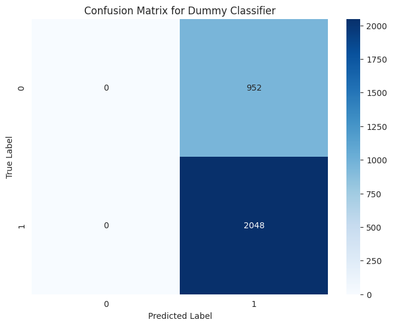

```python
from sklearn.dummy import DummyClassifier
# This model will always predict the class that appears most often in the training dataset
dummy_clf = DummyClassifier(strategy="most_frequent", random_state=42)
dummy_clf.fit(X_train, y_train)

# Predicting on the test data
y_pred_dummy = dummy_clf.predict(X_test)

# Calculating the accuracy
accuracy_dummy = accuracy_score(y_test, y_pred_dummy)
print(f"Baseline Dummy Classifier Accuracy: {accuracy_dummy}")

# Additionally, you might want to see the classification report for the dummy classifier
print(classification_report(y_test, y_pred_dummy))

# And the confusion matrix
dummy_conf_matrix = confusion_matrix(y_test, y_pred_dummy)

# Visualizing the confusion matrix
plt.figure(figsize=(8, 6))
sns.heatmap(dummy_conf_matrix, annot=True, fmt='d', cmap='Blues')
plt.xlabel('Predicted Label')
plt.ylabel('True Label')
plt.title('Confusion Matrix for Dummy Classifier')
plt.show()
```

### Classifier 3 - Clustering

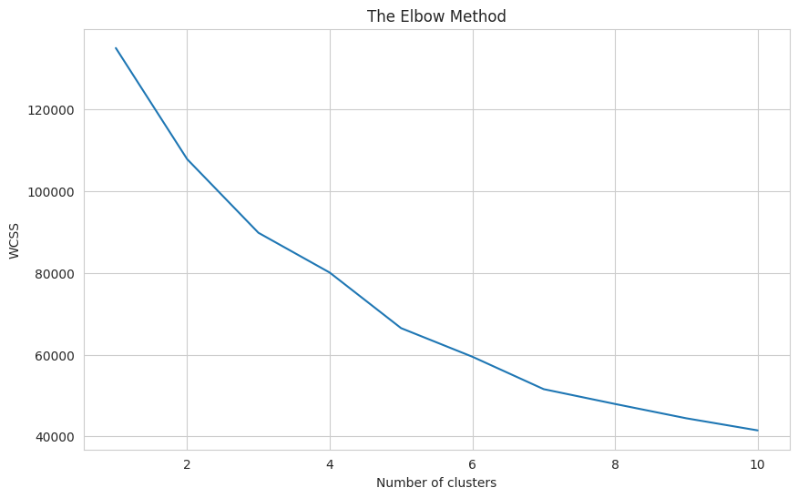

```python
from sklearn.cluster import KMeans
from sklearn.preprocessing import StandardScaler

# Normalize the features
scaler = StandardScaler()
X_scaled = scaler.fit_transform(df[features])

# Elbow Method to find the optimal number of clusters
wcss = []  # Within-Cluster Sum of Square
for i in range(1, 11):  # testing 1 to 10 clusters
    kmeans = KMeans(n_clusters=i, init='k-means++', random_state=42)
    kmeans.fit(X_scaled)
    wcss.append(kmeans.inertia_)

# Plot the WCSS to see the elbow
plt.figure(figsize=(10, 6))
plt.plot(range(1, 11), wcss)
plt.title('The Elbow Method')
plt.xlabel('Number of clusters')
plt.ylabel('WCSS')
plt.show()

k = 6

# Apply KMeans with the chosen 'k'
kmeans = KMeans(n_clusters=k, init='k-means++', random_state=42)
df['Cluster'] = kmeans.fit_predict(X_scaled)

# Now 'Cluster' is a new feature that can be used for further analysis or as an input to a classification model.
```

```python
#Meaning of cluster
df.groupby('Cluster').mean()
```

| Cluster | Emp ID | satisfaction_level | last_evaluation | number_project | average_montly_hours | time_spend_company | Work_accident | promotion_last_5years | is_satisfied | salary_high | salary_low | salary_medium |
| --- | --- | --- | --- | --- | --- | --- | --- | --- | --- | --- | --- | --- |
| 0 | 7292.675013 | 0.605775 | 0.605676 | 3.061928 | 169.802639 | 3.000269 | 0.147550 | 0.0 | 0.603931 | 0.000000 | 1.000000 | 0.000000 |
| 1 | 7312.963518 | 0.594992 | 0.834666 | 4.581731 | 233.948247 | 3.891968 | 0.134050 | 0.0 | 0.696267 | 0.000000 | 1.000000 | 0.000000 |
| 2 | 7260.040502 | 0.636977 | 0.627906 | 3.253280 | 176.073018 | 2.961495 | 0.137193 | 0.0 | 0.695094 | 0.000000 | 0.000000 | 1.000000 |
| 3 | 8463.935622 | 0.636910 | 0.705451 | 3.768240 | 200.102146 | 3.581974 | 0.151931 | 0.0 | 0.740773 | 1.000000 | 0.000000 | 0.000000 |
| 4 | 10113.968652 | 0.656019 | 0.706019 | 3.752351 | 199.849530 | 4.166144 | 0.238245 | 1.0 | 0.771160 | 0.225705 | 0.206897 | 0.567398 |
| 5 | 7614.470098 | 0.599362 | 0.830533 | 4.521928 | 233.230518 | 4.233418 | 0.149692 | 0.0 | 0.701704 | 0.000000 | 0.000000 | 1.000000 |

## Evaluation

Our problem involves predicting whether employees are satisfied or not and we have an imbalanced dataset (for example, very few unsatisfied employees), **F1-score is more suitable**

[output not shown]

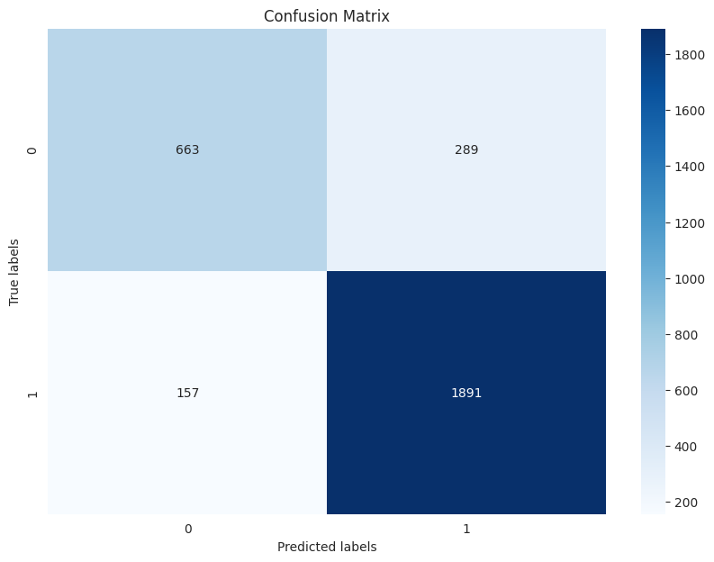

```python
from sklearn.metrics import accuracy_score, precision_score, recall_score, f1_score, confusion_matrix

# Calculate classification metrics
accuracy = accuracy_score(y_test, y_pred)
precision = precision_score(y_test, y_pred, average='weighted') # or 'binary' if you have a binary classification
recall = recall_score(y_test, y_pred, average='weighted') # or 'binary'
f1 = f1_score(y_test, y_pred, average='weighted') # or 'binary'

# Print the classification metrics
print(f"Accuracy: {accuracy}")
print(f"Precision: {precision}")
print(f"Recall: {recall}")
print(f"F1 Score: {f1}")

# Visualize the confusion matrix with Seaborn
plt.figure(figsize=(10, 7))
sns.heatmap(dt_conf_matrix, annot=True, fmt='g', cmap='Blues')  # fmt='g' to avoid scientific notation
plt.xlabel('Predicted labels')
plt.ylabel('True labels')
plt.title('Confusion Matrix')
plt.show()
```

### Random Forest

```
Accuracy: 0.8606666666666667
Precision: 0.8584534104543833
Recall: 0.8606666666666667
F1 Score: 0.8580655504354238
```

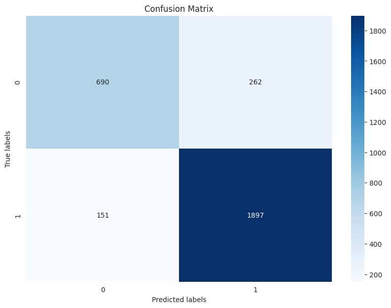

```python
# Calculate classification metrics
accuracy = accuracy_score(y_test, y_pred)
precision = precision_score(y_test, y_pred, average='weighted') # or 'binary' if you have a binary classification
recall = recall_score(y_test, y_pred, average='weighted') # or 'binary'
f1 = f1_score(y_test, y_pred, average='weighted') # or 'binary'

# Print the classification metrics
print(f"Accuracy: {accuracy}")
print(f"Precision: {precision}")
print(f"Recall: {recall}")
print(f"F1 Score: {f1}")

# Visualize the confusion matrix with Seaborn
plt.figure(figsize=(10, 7))
sns.heatmap(rf_conf_matrix, annot=True, fmt='g', cmap='Blues')  # fmt='g' to avoid scientific notation
plt.xlabel('Predicted labels')
plt.ylabel('True labels')
plt.title('Confusion Matrix')
plt.show()
```

```python
C_TP, C_FN, C_FP, C_TN = 0, 0, 5, 10
# Define a function to calculate total cost
def calculate_total_cost(conf_matrix, costs):
    total_cost = (conf_matrix[0, 0] * costs[0] + conf_matrix[0, 1] * costs[1] +
                  conf_matrix[1, 0] * costs[2] + conf_matrix[1, 1] * costs[3])
    return total_cost

# Calculate total costs for each model
total_cost_model1 = calculate_total_cost(dt_conf_matrix, [C_TP, C_FN, C_FP, C_TN])
total_cost_model2 = calculate_total_cost(rf_conf_matrix, [C_TP, C_FN, C_FP, C_TN])

# Compare models
print(f"Total Cost for Decision Tree model: {total_cost_model1}")
print(f"Total Cost for Random Forest Model: {total_cost_model2}")
```

```
Total Cost for Decision Tree model: 19695
Total Cost for Random Forest Model: 19725
```

### Feature Analysis

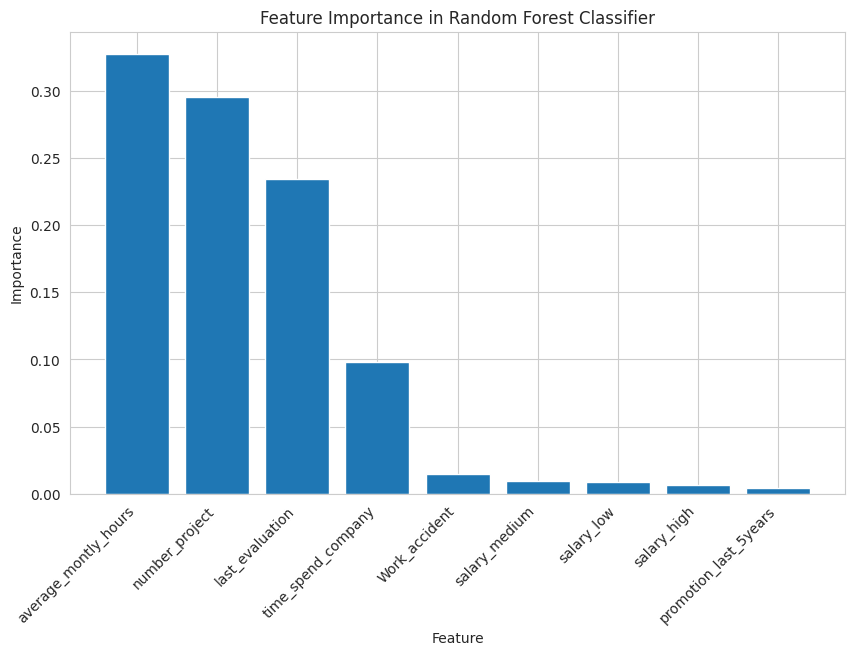

```python
# Train the Random Forest Classifier
best_rf_classifier = RandomForestClassifier(n_estimators=100, random_state=42)
best_rf_classifier.fit(X_train, y_train)

# Create a DataFrame for feature importance
feature_importance_df = pd.DataFrame({
    'Feature': X_train.columns,
    'Importance': best_rf_classifier.feature_importances_
})

# Sort the DataFrame by importance
feature_importance_df = feature_importance_df.sort_values(by='Importance', ascending=False)

# Plot the feature importance
plt.figure(figsize=(10, 6))
plt.bar(feature_importance_df['Feature'], feature_importance_df['Importance'])
plt.xlabel('Feature')
plt.ylabel('Importance')
plt.title('Feature Importance in Random Forest Classifier')
plt.xticks(rotation=45, ha="right")
plt.show()
```

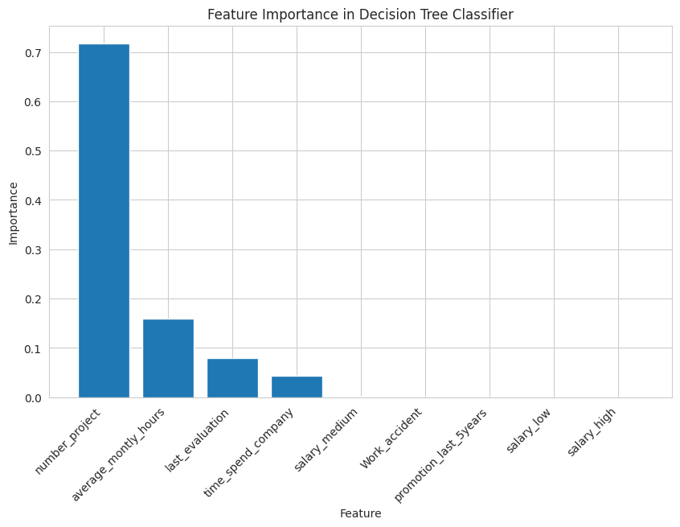

```python
# Train the Decision Tree Classifier
best_dt_classifier = DecisionTreeClassifier(max_depth=5, random_state=42)  # max_depth is just an example parameter
best_dt_classifier.fit(X_train, y_train)

# Create a DataFrame for feature importance
feature_importance_df = pd.DataFrame({
    'Feature': X_train.columns,
    'Importance': best_dt_classifier.feature_importances_
})

# Sort the DataFrame by importance
feature_importance_df = feature_importance_df.sort_values(by='Importance', ascending=False)

# Plot the feature importance
plt.figure(figsize=(10, 6))
plt.bar(feature_importance_df['Feature'], feature_importance_df['Importance'])
plt.xlabel('Feature')
plt.ylabel('Importance')
plt.title('Feature Importance in Decision Tree Classifier')
plt.xticks(rotation=45, ha="right")
plt.show()
```

## Explanation

### Classifier 1 - Decision tree

```python
# Now df has new columns like 'salary_low', 'salary_medium', 'salary_high'
if 'salary' in df.columns:
    df = pd.get_dummies(df, columns=['salary'])


# Selecting features and target
features = ['time_spend_company', 'last_evaluation', 'number_project', 'average_montly_hours', 'Work_accident','promotion_last_5years','salary_low','salary_medium','salary_high']
target = 'satisfaction_level'

# Splitting the data into features (X) and target (y)
X = df[features]
y = df[target]

X_train, X_test, y_train, y_test = train_test_split(X, y, test_size=0.2, random_state=42)

# Train a decision tree classifier
dt_regressor = DecisionTreeRegressor(max_depth=9)
dt_regressor.fit(X_train, y_train)

# Plotting the decision tree
plt.figure(figsize=(30,15))
plot_tree(dt_regressor, feature_names=features, filled=True)
```

[output not shown]

- `time_spend_company`
  - Represents the number of years the employee has spent in the company.
- `last_evaluation`
  - Indicates the performance evaluation score of the employee in their most recent evaluation.
- `number_project`
  - Represents the number of projects the employee has been involved in.
- `average_montly_hours`
  - Represents the average number of monthly working hours of the employee.
- `Work_accident`
  - Indicates whether the employee has been involved in a work-related accident.
- `promotion_last_5years`
  - Indicates whether the employee has been promoted in the last 5 years
- `salary_low, salary_medium, salary_high`
  - They represent different salary levels (low, medium, high) of the employees
- `target: satisfaction_level`
  - Represents the level of satisfaction of the employees

```python
features = ['time_spend_company', 'last_evaluation', 'number_project', 'average_montly_hours', 'Work_accident','promotion_last_5years','salary_low','salary_medium','salary_high']
target = 'satisfaction_level'
```

### Classifier 2 - Random Forest

```python
# Splitting the dataset into training and testing sets
X_train, X_test, y_train, y_test = train_test_split(X, y, test_size=0.2, random_state=42)

# Train a Random Forest Regressor
rf_regressor = RandomForestRegressor(n_estimators=100, random_state=42)
rf_regressor.fit(X_train, y_train)

# Predicting on the test set
y_pred = rf_regressor.predict(X_test)

# Calculating the Root Mean Squared Error (RMSE)
rmse = np.sqrt(mean_squared_error(y_test, y_pred))
print(f"Root Mean Squared Error (RMSE): {rmse}")
```

[output not shown]

Similarly, the second classifier utilizes a Random Forest model to predict employee satisfaction using the same main attributes. The data is loaded, features are selected, and the dataset is split into training and testing sets.

Feature Importance Analysis:

```python
# Train the Random Forest Regressor
best_rf_regressor = RandomForestRegressor(n_estimators=100, random_state=42)
best_rf_regressor.fit(X_train, y_train)

# Create a DataFrame for feature importance
feature_importance_df = pd.DataFrame({
    'Feature': X_train.columns,
    'Importance': best_rf_regressor.feature_importances_
})

# Sort the DataFrame by importance
feature_importance_df = feature_importance_df.sort_values(by='Importance', ascending=False)

# Plot the feature importance
plt.figure(figsize=(10, 6))
plt.bar(feature_importance_df['Feature'], feature_importance_df['Importance'])
plt.xlabel('Feature')
plt.ylabel('Importance')
plt.title('Feature Importance in Random Forest Regressor')
plt.xticks(rotation=45, ha="right")
plt.show()
```

[output not shown]

```python
X_test.iloc[[1]]
```

[output not shown]

Show the instance of interest - a row in the dataframe

```python
print(X_test.sample(1))
```

[output not shown]

### Classifier 3 - Clustering

```python
# Normalize the features
scaler = StandardScaler()
X_scaled = scaler.fit_transform(df[features])

# Elbow Method to find the optimal number of clusters
wcss = []
for i in range(1, 11):  # testing 1 to 10 clusters
    kmeans = KMeans(n_clusters=i, init='k-means++', random_state=42)
    kmeans.fit(X_scaled)
    wcss.append(kmeans.inertia_)

# Plot the WCSS to see the elbow
plt.plot(range(1, 11), wcss)
plt.title('The Elbow Method')
plt.xlabel('Number of clusters')
plt.ylabel('WCSS')
plt.show()

# Choose the number of clusters (k) and apply KMeans
k = 7
kmeans = KMeans(n_clusters=k, init='k-means++', random_state=42)
y_clusters = kmeans.fit_predict(X_scaled)
```

[output not shown]

```python
kmeans.fit(X)
```

```python
labels = kmeans.labels_
labels
```

[output not shown]

```python
centers = centers = kmeans.cluster_centers_
centers
```

[output not shown]

```python
cluster_counts = data_for_cluster['cluster_k-means'].value_counts()
print("\nNumber of Instances in Each Cluster:")
print(cluster_counts)
```

[output not shown]

```python
inertia = kmeans.inertia_
inertia
```

[output not shown]

Clustering Visualization

```python
plt.scatter(X[:, 0], X[:, 1], c=labels, cmap='rainbow')
plt.scatter(centers[:, 0], centers[:, 1], marker='*', s=100, c='black')
plt.show()
```

[output not shown]

## Conclusion

**Which Machine Learning Result Has the Highest Value and Is Most Interesting?**

```
Total Cost for Decision Tree model: 19695
Total Cost for Random Forest Model: 19725
```

**What Setting Provided the Best Result?**

Model Parameters: For the Decision Tree, varying the max_depth parameter and for the Random Forest, adjusting the n_estimators parameter, gave insights into the best settings. The optimal value for these parameters: Best max_depth by Accuracy: 13 Best n_estimators by Accuracy: 150

**Which Attributes Are the Most Important?** Feature Importance: Feature importance analysis identified which features most significantly impact the model's predictions.

For Decision Tree:

```
number_project
average_hours_monthly,
last_evaluation
```

For Random Forest:

```
average_hours_monthly,
number_project,
last_evaluation,
time_spend_company
```